# 이스탄불 — 두 대륙의 교차점

동과 서가 만나는 도시의 1,500년

저자

Culture Voyager

공개

2026년 6월 6일

← Culture Voyager 목록으로

E축 : 언젠가 가볼 곳

페리가 보스포루스 해협을 가로지르는 순간, 아시아에서 유럽으로 넘어가는 그 15분 동안, 나는 인생에서 가장 저렴한 대륙 이동을 경험한다는 상상을 한다. 티켓 값은 몇 리라. 그리고 창밖으로는 노을이 타는 미나레트 첨탑들이 있다.

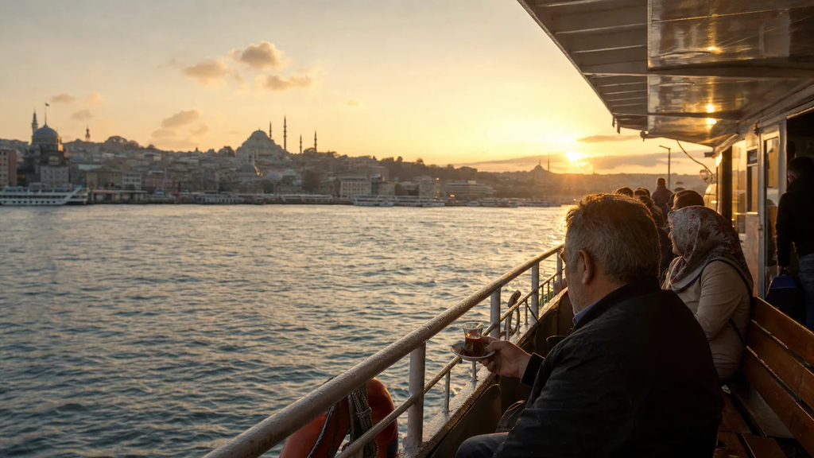

보스포루스의 저녁 페리. 이스탄불에서는 평범한 퇴근길이 대륙을 건너는 여행이 된다.

## 보스포루스를 건너며: 세계에서 가장 이상한 출퇴근

이스탄불 사람들에게 출퇴근이란 대륙 횡단이다.

아시아 쪽에 집이 있고 유럽 쪽에 회사가 있다면, 매일 아침 카드몌이나 위스퀴다르 선착장으로 나가 페리에 오른다. 물살이 빠른 보스포루스를 가르며 에미뇌뉘나 베식타스로 향하는 15분 동안, 그들은 차이를 홀짝이거나 창밖을 멍하니 바라보거나 스마트폰을 들여다본다. 비범한 일상. 하루 두 번, 아시아와 유럽 사이를 오간다.

지리학적으로는 단순하다. 보스포루스 해협은 폭이 550미터에서 3.5킬로미터 사이를 오가는, 지구상에서 가장 빈번하게 통행되는 수로 중 하나다. 하지만 그 물길이 품은 의미는 단순하지 않다. 이쪽이 아시아고 저쪽이 유럽이라는 선언은 인간이 그어놓은 선이지만, 페리 위에서 그 선은 느낌표처럼 실재한다.

나는 아직 이스탄불에 가보지 못했다. 하지만 어떤 도시들은 직접 발을 딛기 전부터 이미 상상 속에 완성되어 있다. 이스탄불이 그런 도시다. 보스포루스 저녁 페리의 이미지 — 주황빛 물결 위로 아야소피아의 실루엣이 떠오르는 그 장면 — 는 내 머릿속에서 수십 번 재생되었다. 현실의 이스탄불은 아마 그 이미지와 다를 것이다. 더 소란스럽고, 더 복잡하고, 덜 로맨틱할 것이다. 그렇지만 동시에 더 진짜일 것이다.

이스탄불은 두 대륙에 걸쳐 있는 유일한 대도시다. 그 사실 하나만으로도 이 도시는 세계의 모든 정체성 논쟁을 체화하고 있다. “당신은 동양인입니까, 서양인입니까?”라는 질문을 도시 스케일로 던지면, 이스탄불은 “그 질문 자체가 잘못됐다”라고 대답하는 것처럼 보인다. 물 위에 다리를 놓는 대신, 그냥 두 곳에 동시에 존재하기로 한 것처럼.

“이스탄불은 선택을 거부한 도시다. 동양도, 서양도, 고대도, 근대도 — 이 도시는 그 모순들을 지도 위에 펼쳐놓고 ’이게 나야’라고 말한다.”

## 아야소피아: 건물이 역사가 될 때

건물이 1,500년을 살아남으면 어떤 일이 벌어지는가.

아야소피아(Hagia Sophia)는 537년에 비잔티움 황제 유스티니아누스 1세가 콘스탄티노폴리스에 세운 기독교 대성당으로 시작했다. 당시 그것은 세계에서 가장 큰 내부 공간을 가진 건물이었고, 약 1,000년 동안 그 기록을 유지했다. 천장의 돔은 지름이 31미터, 지상 55미터 높이에 떠 있다. 비잔티움 건축가들은 그 돔이 하늘에서 황금 사슬로 매달려 있는 것처럼 보이도록 설계했다고 전한다. 그리고 처음 그 건물에 들어선 사람들은 실제로 그렇게 느꼈다고 기록했다.

1453년, 오스만 제국의 술탄 메흐메트 2세가 콘스탄티노폴리스를 함락시켰다. 도시의 이름은 이스탄불로 바뀌었고, 아야소피아는 모스크가 되었다. 기독교 모자이크화들은 석회로 덮였고, 네 개의 미나레트가 외부에 추가되었다. 이슬람 서예가 벽면을 채웠다. 그러나 건물의 뼈대는 그대로였다. 비잔티움의 돔은 오스만의 하늘 아래서 그대로 하늘을 향해 솟아 있었다.

1934년, 터키 공화국의 설립자 케말 아타튀르크는 아야소피아를 박물관으로 전환했다. 기독교와 이슬람 양쪽 모두를 중립화하는 결정이었다. 덮여 있던 비잔티움 모자이크들이 일부 복원되어 그 위로 알라의 이름을 담은 거대한 원형 현판과 나란히 존재하게 되었다. 예수와 성모 마리아의 황금 모자이크 옆에 “알라”라고 쓰인 검은 현판. 이 공존이 80년간 지속되었다.

그리고 2020년, 터키 정부는 아야소피아를 다시 모스크로 전환했다.

이 건물의 역사는 단순한 건축 기록이 아니다. 그것은 문명의 밀물과 썰물을 물리적으로 기록한 일지다. 비잔티움 제국의 영광, 오스만의 정복, 세속 공화국의 탄생, 그리고 다시 이슬람 국가로의 선회. 하나의 건물이 그 모든 것을 피부로 겪었다. 석회로 덮이고, 다시 복원되고, 다시 덮이면서.

[figure not shown]

황금 모자이크와 미나레트가 한 시야에 겹치는 아야소피아. 건축은 지워진 역사까지 품는다.

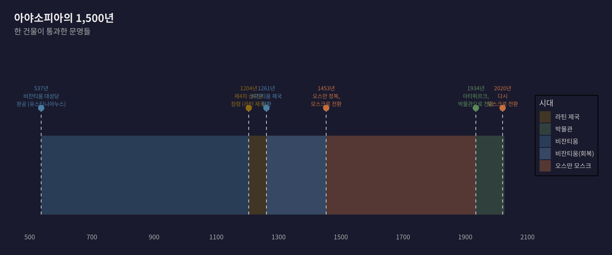

그림 1: 아야소피아: 1,500년의 변신

내가 이 건물에 대해 생각할 때 자꾸 떠오르는 것은 그 석회의 층위다. 덮고, 덮이고, 다시 벗겨지는 과정. 역사가 단순히 앞으로만 흐르지 않는다는 것, 어떤 것들은 지워지고 또 어떤 것들은 다시 돌아온다는 것. 아야소피아는 그 사실을 건물 자체로 증명하는 것처럼 보인다.

한국에도 비슷한 건물들이 있을까 생각해본다. 식민지 시절 조선총독부 건물이 해방 이후 국립중앙박물관으로 쓰이다가 1995년 철거된 것. 경복궁 근정전이 일제강점기를 관통해 살아남은 것. 우리도 건물로 역사를 쓴다. 다만 아야소피아처럼 1,500년을 한 자리에서 버텨낸 건물이 우리에게는 없다. 그 무게가, 그 축적이 이스탄불을 특별하게 만든다.

## 그랜드 바자르: 쇼핑몰의 원형

1461년에 문을 연 가게들이 아직도 영업 중이다.

이스탄불의 그랜드 바자르(Kapalıçarşı, 카팔르차르슈)는 세계에서 가장 오래된 대형 쇼핑몰이다. 6만 제곱미터 면적에 61개의 아케이드, 4,000개가 넘는 점포. 하루 유동 인구가 최대 40만 명. 이 숫자들을 늘어놓으면 그냥 커다란 시장처럼 들리지만, 그 역사적 맥락을 붙이면 이야기가 달라진다.

현대의 쇼핑몰은 아마 이 바자르로부터 계보를 이어받았을 것이다. 지붕으로 덮인 상업 공간, 섹션별로 구분된 업종, 통일된 조명과 보안. 그랜드 바자르는 그 모든 것을 600년 전에 이미 구현했다. 금은 세공인들의 구역, 가죽 상인들의 구역, 양탄자 상인들의 구역, 향신료 상인들의 구역. 오스만 제국의 행정력은 이 거대한 상업 공간에 질서를 부여했고, 그 질서는 지금도 느슨하게나마 유지된다.

하지만 바자르의 진짜 의미는 상품이 아니라 교환에 있었다. 오스만 제국의 전성기, 이스탄불은 세계 무역의 허브였다. 실크로드의 서쪽 끝, 지중해와 흑해를 연결하는 지점. 중국의 비단, 인도의 향신료, 베네치아의 유리, 이집트의 면화, 페르시아의 카펫이 이 도시를 거쳐 유통되었다. 그랜드 바자르는 그 교류의 물리적 공간이었다.

상인들은 단순히 물건만 교환하지 않았다. 언어, 요리법, 종교 이야기, 정치적 소문. 카라반세라이(대상여관)에 모여든 상인들 사이에서 세계는 교환되었다. 지금 우리가 “글로벌화”라고 부르는 것의 전근대적 버전이 바자르에서 이미 작동하고 있었다.

나는 이 공간을 상상할 때 냄새부터 생각한다. 향신료, 가죽, 사람 냄새, 그리고 어딘가에서 끓고 있을 차이의 향. 시각적 화려함보다 먼저 후각이 도착할 것 같은 그런 공간. 서울의 광장시장도 비슷한 냄새를 가지고 있지만, 600년의 두께는 없다.

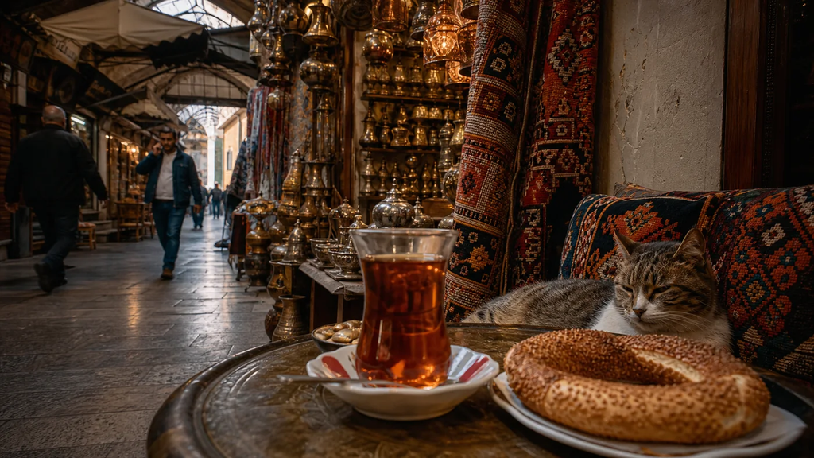

그랜드 바자르의 차이와 시밋, 그리고 자리를 먼저 차지한 고양이. 도시의 문화는 거창한 기념물보다 일상에 오래 남는다.

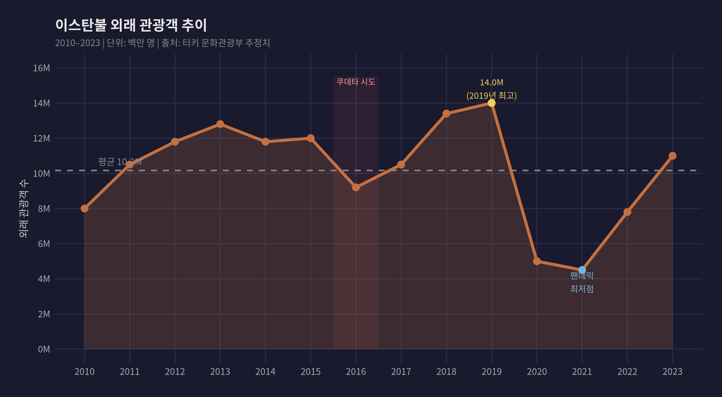

그림 2: 이스탄불 연간 외래 관광객 추이 (2010–2023)

## 차이, 시밋, 그리고 고양이들

어떤 도시를 이해하려면 그곳 사람들이 매일 무엇을 먹고 마시는지를 보면 된다.

이스탄불 사람들은 하루에 몇 잔의 차이(çay)를 마시는가. 정확한 통계를 인용할 자신은 없지만, 터키는 1인당 차 소비량에서 세계 최상위권을 다툰다. 차이는 단순한 음료가 아니라 사회적 행위다. 가게에 들어가면 주인이 차이를 내온다. 협상이 시작되기 전에 차이가 먼저다. 택시 기사에게 길을 물으면 차이 한 잔을 권한다. 차이는 거래이기 전에 인사다.

잔 모양도 특별하다. 허리가 잘록하게 들어간 작은 튤립 모양 유리잔. 이 잔은 터키 차이의 색을 감상하기 위해 설계되었다고 한다 — 진한 루비색 차에 조금씩 뜨거운 물을 섞어 원하는 농도로 조절하는 방식. 미적인 것과 실용적인 것이 결합된, 작지만 완성도 높은 물건이다.

한국의 차 문화와 비교해보면 흥미롭다. 한국에도 전통 차 문화가 있지만, 그것은 이스탄불의 차이 문화처럼 일상의 모세혈관을 타고 흐르지는 않는다. 한국에서 차는 점점 “건강”의 맥락에서 소비되거나, 인스타그램의 맥락에서 소비된다. 이스탄불의 차이는 그냥 사람 사이에 있다.

시밋(simit)은 또 다른 이스탄불의 상징이다. 참깨를 잔뜩 묻힌 빵의 일종으로, 길거리 카트에서 팔리거나 가방에 한 꾸러미씩 넣고 다니며 파는 행상인들이 있다. 가격은 극히 저렴하고, 아침 식사로, 간식으로, 출근길에 먹힌다. 이스탄불 사람들의 손에는 차이 잔 아니면 시밋이 들려 있다는 말이 있을 정도다.

그리고 고양이들.

이스탄불의 고양이들은 유명하다. 도시 전체가 그들의 영토다. 카페 의자에 앉아 있고, 생선 가게 앞을 어슬렁거리고, 모스크 계단에서 낮잠을 잔다. 이 고양이들은 유기묘가 아니다. 길고양이지만, 도시 전체가 주인인 고양이들이다. 이스탄불 사람들은 건물 밖에 고양이 집을 짓고, 사료를 두고, 수의사 치료를 받게 한다. 이 집단적 돌봄은 조직화된 자원봉사가 아니라 그냥 일상이다.

2016년에 나온 다큐멘터리 영화 「케디(Kedi)」는 이 고양이들의 도시를 담았다. 일곱 마리 고양이의 시점에서 바라본 이스탄불. 영화는 고양이들의 이야기이기도 하고, 고양이들을 통해 본 이스탄불 사람들의 이야기이기도 하다. 이 영화를 보고 나면 이스탄불을 사람의 도시로 보는 것과 다른 방식으로 보게 된다.

[video not shown]

「케디 (Kedi, 2016)」 공식 예고편

고양이들이 왜 이스탄불에서 이토록 사랑받는가. 이슬람 전통에서 고양이는 신성한 동물로 여겨진다는 설명이 있다. 예언자가 고양이를 아꼈다는 이야기가 전해진다. 하지만 그것만이 아닐 것이다. 수백 년 동안 항구 도시로 살아온 이스탄불에서 쥐를 잡는 고양이는 실용적인 존재였다. 신성함과 실용성이 겹쳐진 자리에 이스탄불의 고양이 문화가 있다.

## 저녁 기도의 소리

하루 다섯 번, 이스탄불의 하늘은 다른 도시가 경험하지 못하는 것을 경험한다.

에잔(ezan), 예배 시간을 알리는 기도 소리가 도시의 수십 개 모스크에서 동시에 울려 퍼진다. 저녁 기도(akşam namazı)는 해 질 무렵에 시작된다. 보스포루스 위로 노을이 깔리는 시간, 아야소피아와 술탄아흐메트 모스크의 미나레트들이 저 멀리 실루엣으로 남아 있을 때, 에잔이 도시 전체를 채운다.

이 소리는 종교적 행위이지만 동시에 도시적 경험이기도 하다. 증폭 장치를 통해 퍼지는 목소리들이 서로 약간씩 어긋나며 겹쳐지고, 그 불완전한 합창이 도시 전체에 퍼진다. 어떤 관광객들은 이것을 소음이라고 느끼고, 어떤 관광객들은 압도적인 경험이라고 말한다. 이스탄불 사람들에게 그것은 그냥 하루의 리듬이다.

이 소리가 없는 이스탄불을 상상하면 도시의 절반이 사라지는 느낌이 든다. 아야소피아의 돔도, 보스포루스의 석양도, 그랜드 바자르의 소란도 — 저녁 기도 소리는 그것들을 연결하는 음향적 실이다.

나는 이 소리를 들어본 적이 없다. 영상으로, 음원으로는 들었지만, 도시 전체에 퍼지는 그 소리를 실제로 경험한 적은 없다. 그래서인지 이 소리는 이스탄불에 가야 하는 이유 목록에서 계속 상위권을 차지한다. 사진으로 찍을 수 없고, 기념품 가게에서 살 수 없는 것.

[video not shown]

드론으로 본 보스포루스의 황혼 — 에잔이 울려 퍼지는 시간

## 동과 서 사이: 이스탄불의 문화 좌표

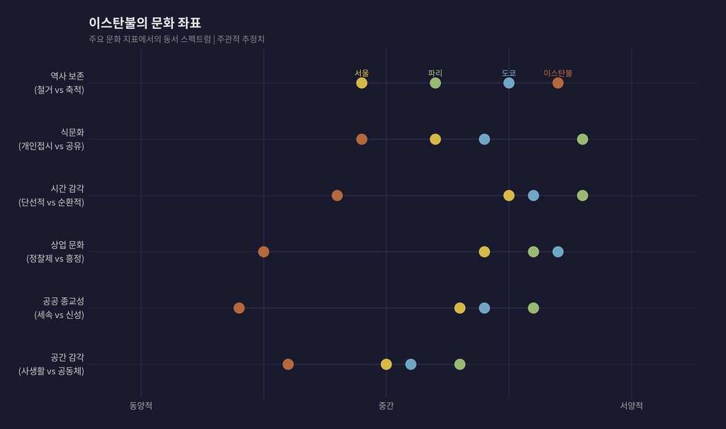

그림 3: 이스탄불의 문화 좌표 — 주요 지표에서의 동서 스펙트럼

이 차트는 엄밀한 데이터가 아니다. 주관적 인상들을 시각화한 것이다. 그래도 한 가지는 보인다 — 이스탄불은 대부분의 지표에서 스펙트럼의 “동양적” 쪽에 더 가까이 위치하면서도, “역사 보존” 지표에서는 오히려 서양 도시들보다도 더 높은 점수를 받는다. 이 불균일함이 이스탄불의 성격이다. 깔끔하게 분류되지 않는다.

서울은 어디에 있는가. 나는 의도적으로 서울을 이 차트에 넣었다. 우리도 비슷한 질문을 안고 있기 때문이다. “한국은 동양인가 서양인가”라는 질문은 이스탄불에 대한 질문만큼 오래되었고, 아마 비슷한 방식으로 잘못 설정된 질문일 것이다.

## 오르한 파묵과 ‘휘준’: 도시의 우울에 대하여

이스탄불을 이야기할 때 빠질 수 없는 단어가 있다. 휘준(hüzün).

이 터키어 단어는 단순히 “슬픔”으로 번역되지 않는다. 개인의 슬픔이 아니라 집단적 멜랑콜리. 한때 위대했던 것을 잃은 도시, 제국의 영광이 물러간 자리에 남은 쓸쓸함. 이스탄불 태생의 소설가는 자신의 회고록에서 이 감정이 이스탄불의 공기 속에 녹아 있다고 썼다. 무너지는 오스만 저택들, 빈 보스포루스 페리들, 겨울 안개 속에 잠긴 해협.

그런데 흥미로운 것은, 휘준이 단순한 비통함이 아니라 일종의 자부심을 동반한다는 점이다. 이스탄불 사람들은 자신들의 도시가 가진 멜랑콜리를 부끄럽게 여기지 않는다. 그것은 깊이의 증거다. 실패를 경험한 사람만이 가질 수 있는 두께.

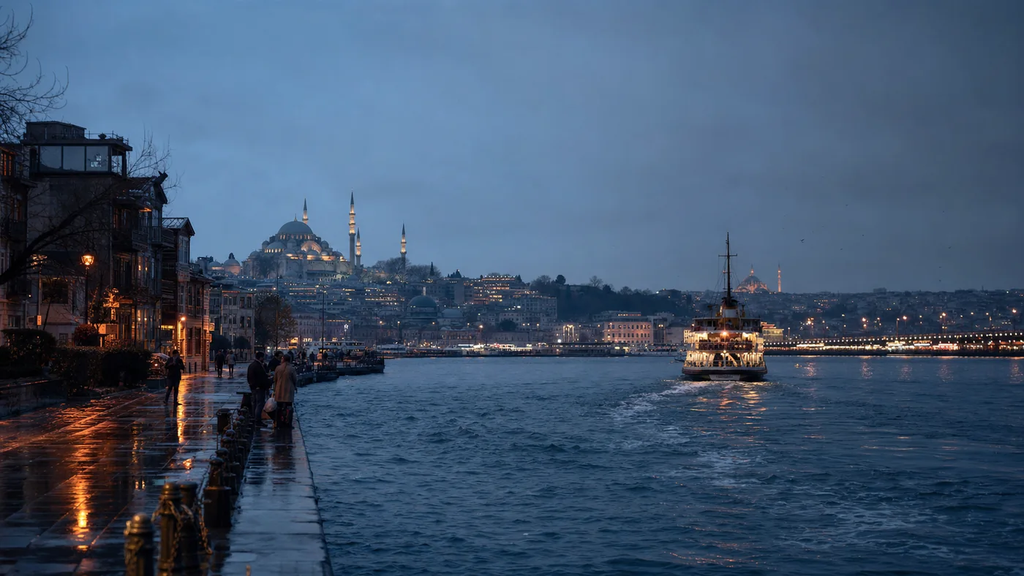

비가 그친 저녁, 보스포루스를 멀어지는 페리. 휘준은 혼자만의 슬픔이 아니라 도시가 함께 간직한 기억에 가깝다.

여기서 나는 한국의 한(恨)을 생각한다. 직접적인 등가물은 아니다. 한은 더 개인적이고, 더 뜨겁고, 더 직접적으로 억울함과 연결된다. 반면 휘준은 더 도시적이고, 더 차갑고, 더 집단적이다. 그러나 둘 다 같은 방향을 향한다 — 상실을 감정의 자원으로 전환하는 능력.

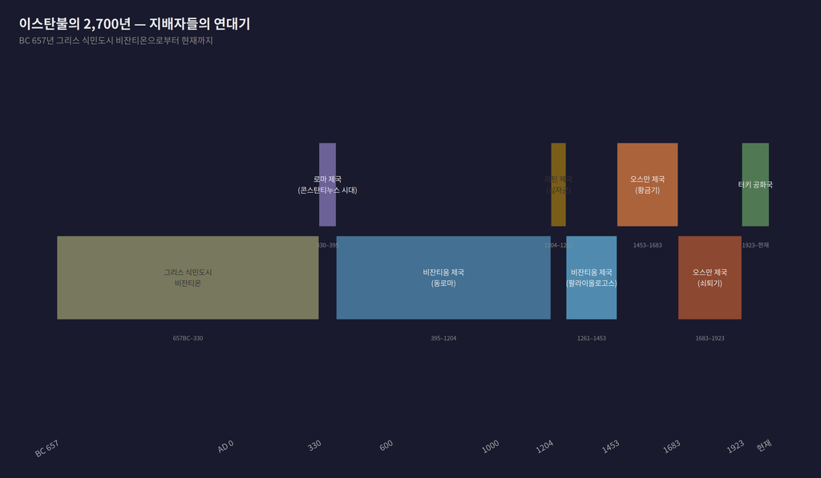

그림 4: 이스탄불을 거쳐간 지배자들 — 문명의 연대기

2,700년의 역사 위에 사는 도시. 이스탄불 사람들이 어떻게 현재를 살아가는지 상상해본다. 지하철 공사를 하다 비잔티움 시대 유물이 나오는 것이 뉴스가 아닌 도시. 서울에서도 광화문 광장 공사 중 조선시대 도로가 발견되는 일이 있지만, 이스탄불의 지층은 그보다 열 배쯤 두껍다.

휘준은 그 두께에서 온다. 너무 많은 것이 왔다 갔다. 너무 많은 것이 쌓이고 사라졌다. 그 무게를 의식하며 사는 것 — 그것이 이스탄불 특유의 감수성을 만든다.

## 선택하지 않는다는 선택

이스탄불은 결정을 거부한다.

동양인가 서양인가. 이슬람 국가인가 세속 국가인가. 전통인가 근대인가. 유럽인가 아시아인가. 이 모든 이분법 앞에서 이스탄불은 “둘 다”라고 대답하거나, 아니면 아예 대답을 거부하는 것처럼 보인다.

2,700년 전 그리스 식민도시로 시작해서, 로마의 수도가 되고, 비잔티움 기독교 문명의 심장이 되고, 오스만 이슬람 제국의 수도가 되고, 세속 공화국의 최대 도시가 된 곳. 그 모든 정체성이 덧칠되어 있다. 어떤 것도 완전히 지워지지 않았고, 어떤 것도 완전히 남지 않았다.

서울도 비슷한 질문들을 받는다. K-팝, K-드라마, K-푸드 — 이 “K-” 접두어들은 한국이 글로벌 문화 시장에서 뚜렷한 정체성을 가지고 있다는 증거처럼 보이지만, 동시에 그 정체성이 무엇인지를 설명하려 할 때 말이 어려워진다. 조선의 유교적 질서와 386세대의 민주화 운동과 IMF 위기와 BTS가 어떻게 같은 문화적 DNA를 공유하는가.

이스탄불을 바라보며 나는 그 질문이 잘못 설정되어 있다는 것을 배운다. 정체성은 하나의 명사가 아니라 동사들의 집합이다. 이스탄불이 “이것이다”라고 설명되는 것이 아니라, 이스탄불이 계속 “무언가를 하고 있다”는 것 — 두 대륙에 걸쳐 서 있고, 기도 소리를 울리고, 고양이를 돌보고, 차이를 내오고, 바자르에서 흥정하고, 페리로 대륙을 건넌다.

“가장 아름다운 도시들은 자신의 모순을 해결하려 하지 않는 도시들이다. 이스탄불은 모순들을 건물로 쌓고, 그 건물 위에서 매일 차이를 마신다.”

어느 저녁, 에미뇌뉘 선착장 근처 찻집에 앉아 튤립 모양 유리잔을 손에 들고 보스포루스를 바라보는 상상을 한다. 해가 지고 있고, 술탄아흐메트의 여섯 미나레트가 노을 속에서 윤곽만 남긴다. 에잔이 시작된다. 한 모스크에서, 그 다음 다른 모스크에서, 그 다음 또 다른 곳에서. 소리들이 겹치고, 도시 전체가 그 음파 안에 잠긴다.

페리가 아시아에서 유럽으로, 유럽에서 아시아로 물살을 가른다.

나는 아직 이스탄불에 가보지 못했다. 그래서 이 도시는 아직도 완성되지 않은 상상 속에 있다. 가봤다면 달라졌을 것이다. 실망했을 수도 있고, 예상보다 훨씬 좋았을 수도 있다. 하지만 상상 속의 이스탄불은 여전히 이 모든 모순들이 완벽하게 유예된 채로 저녁 하늘 아래 서 있다.

그것도 나쁘지 않다고 생각한다. 어떤 도시들은 가기 전이 가장 아름다운 법이니까.

## 데이터 노트

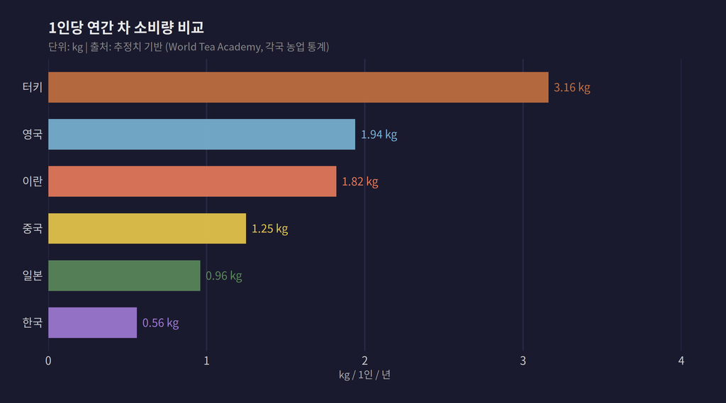

그림 5: 차 문화 비교 — 한국, 터키, 일본, 영국 (1인당 연간 소비량 추정치)

터키의 1인당 차 소비량은 세계 최상위권이다. 한국의 약 5.6배. 이 숫자는 단순한 음료 소비 통계가 아니라 두 문화가 일상에서 음료에 부여하는 의미의 차이를 반영한다. 한국에서 차는 최근 들어 다시 주목받고 있지만, 아직 이스탄불의 차이처럼 사회적 기름 역할을 하지는 않는다. 한국의 그 역할은 오히려 커피가 하고 있다 — 카페 공화국의 커피.

*이 글은 직접 방문한 기록이 아닌, 자료와 상상을 바탕으로 쓴 문화 에세이입니다. 이스탄불은 언젠가 가볼 곳 목록의 맨 위에 있습니다.*

← Culture Voyager 목록으로